# ggplot2 Tutorial

## Color scales

Often, we use color or fill to visualise categorical data, such as the quality of the cut in our graph about diamonds. By default, ggplot will use a rainbow theme. However, many more palettes are available. We can add these by using `scale_color_brewer` or `scale_fill_brewer`, depending on whether it concerns a color or fill-color. Both layers have a palette argument, of which the possible values can be found below.

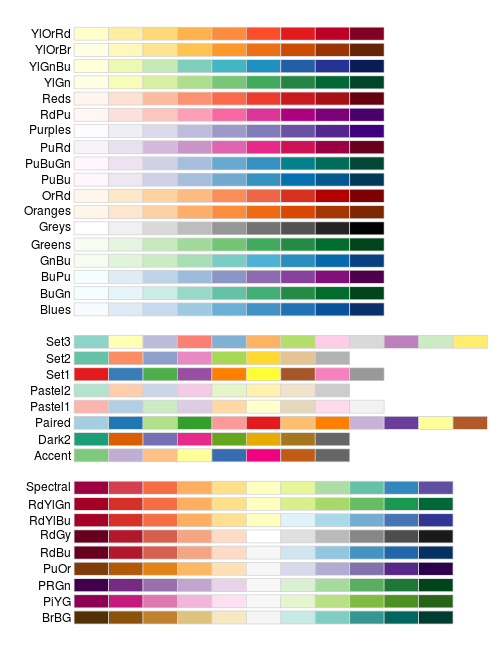

R color palettes

For instance, let’s use the Set1 pallete.

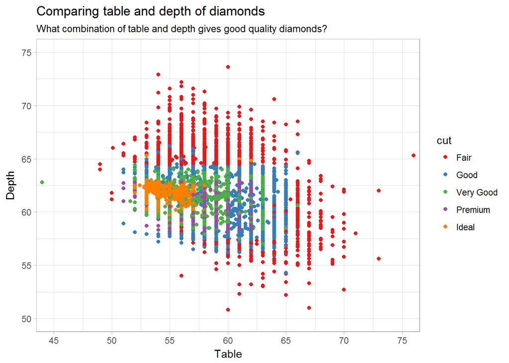

```r
ggplot(diamonds) +
    geom_point(aes(table, depth, col = cut)) +
    labs(title = "Comparing table and depth of diamonds",
         subtitle = "What combination of table and depth gives good quality diamonds?",
         x = "Table",
         y = "Depth") +
    theme_light() +
    coord_cartesian(xlim = c(45,75), ylim = c(50, 75)) +
    scale_x_continuous(breaks = seq(45,75,5)) +
    scale_y_continuous(breaks = seq(50,75,5)) +
    scale_color_brewer(palette = "Set1")
```

The scale_._brewer functions also have the argument `name`, which we can use to set the name of the legend, and the argument `guide`, which will remove the legend if set to FALSE.

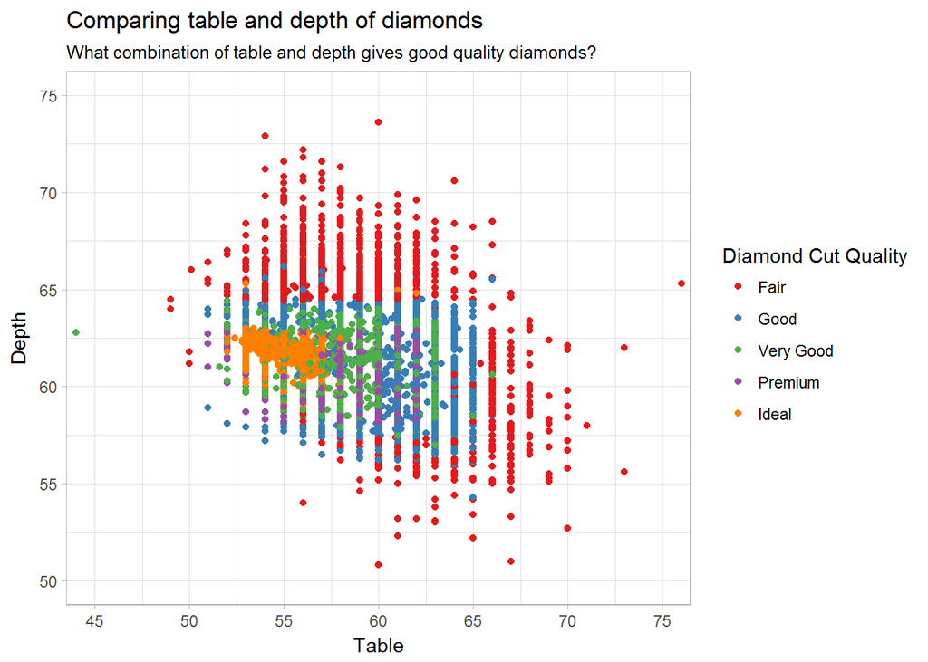

```r
ggplot(diamonds) +
    geom_point(aes(table, depth, col = cut)) +
    labs(title = "Comparing table and depth of diamonds",
         subtitle = "What combination of table and depth gives good quality diamonds?",
         x = "Table",
         y = "Depth") +
    theme_light() +
    coord_cartesian(xlim = c(45,75), ylim = c(50, 75)) +
    scale_x_continuous(breaks = seq(45,75,5)) +
    scale_y_continuous(breaks = seq(50,75,5)) +
    scale_color_brewer(palette = "Set1", name = "Diamond Cut Quality")
```

Next to the standard color palettes avaiable, many more can be found in the packages `ggthemes` and `ggsci`. They can be used by adding *scale_color*+ name of the palette. Feel free to explore some more!

# Advanced plots

Often, you want to compare plots for different categories of a variable. In our example, we looked for which combinations of table and depth, the cut of the diamond was good. We now want to know whether there is a difference between the 8 different clarity levels in the data. One way would be to make 8 different plots, one for each of the levels. However, this would be cumbersome to put together. Fortunately, we can use the function `facet_grid` to create different plots within a plot.

## Using Facets

This function expects a formula in the form of `A ~ B` where A and B are two categorical variables. For each combination of values of A and B, a different plot will be constructed, and they will be arranged in a grid where the values of A each constitute a row and the values of B each constitute a column. Comparisons of more than 2 variables are possible using a formula of the form `A + B ~ C`. A comparison along one variable is possible by using a dot instead of a variable name, i.e. `. ~ A` or `A ~ .` .

In the following plot, we use facets to redraw our plot for each of the clarity levels. Furthermore, the legend is placed on top to create more space.

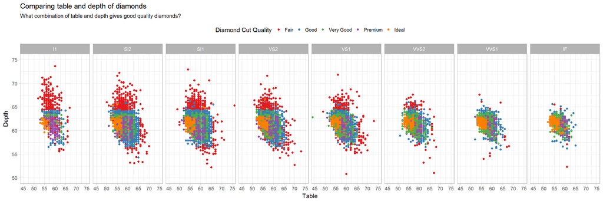

```r
ggplot(diamonds) +
    geom_point(aes(table, depth, col = cut)) +
    labs(title = "Comparing table and depth of diamonds",
         subtitle = "What combination of table and depth gives good quality diamonds?",
         x = "Table",
         y = "Depth") +
    theme_light() +
    coord_cartesian(xlim = c(45,75), ylim = c(50, 75)) +
    scale_x_continuous(breaks = seq(45,75,5)) +
    scale_y_continuous(breaks = seq(50,75,5)) +
    scale_color_brewer(palette = "Set1", name = "Diamond Cut Quality") +
    facet_grid(. ~ clarity) +
    theme(legend.position = "top")
```

An alternative, mostly suitable for comparisons along one variable, is facet_wrap. Instead of making one row (like facet_grid does), it will order the plots in a grid with a specified number of columns or rows. Below, we ordered them in 3 columns.

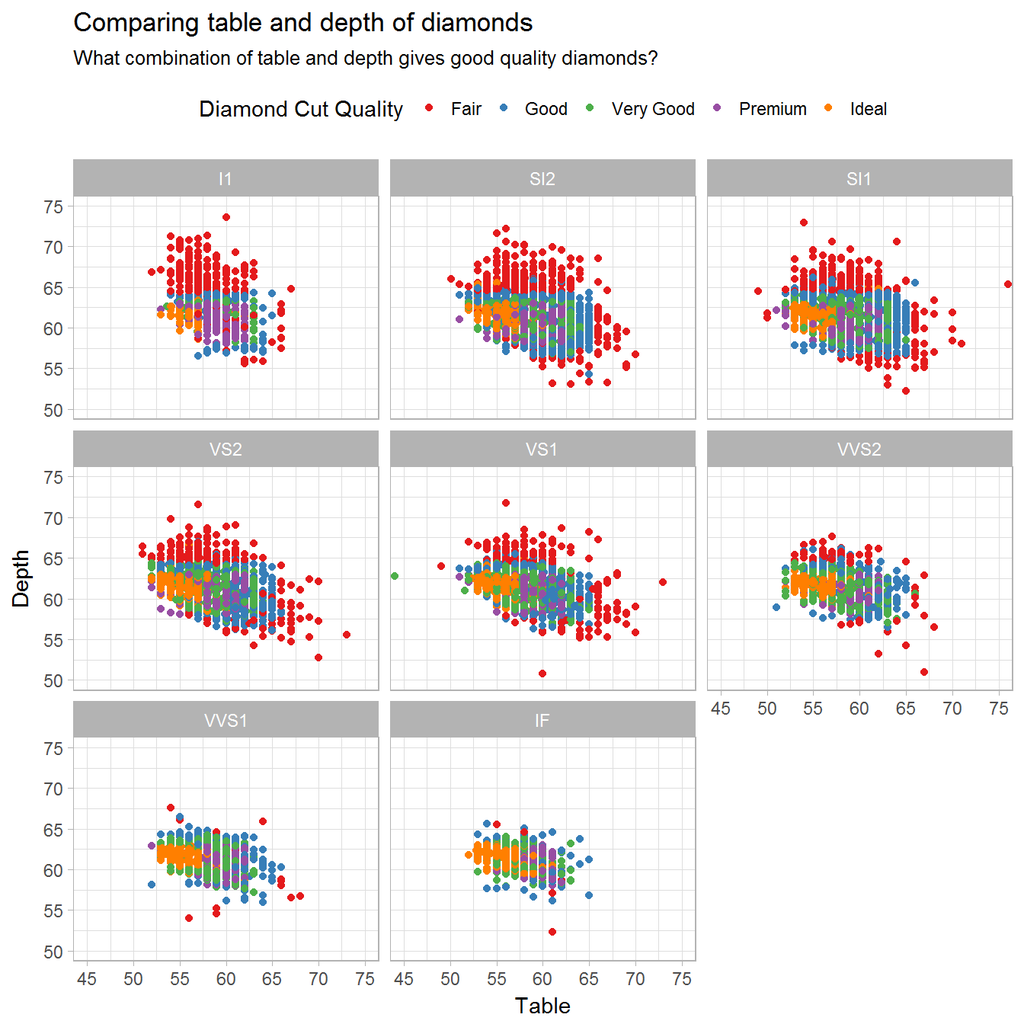

```r
ggplot(diamonds) +
    geom_point(aes(table, depth, col = cut)) +
    labs(title = "Comparing table and depth of diamonds",
         subtitle = "What combination of table and depth gives good quality diamonds?",
         x = "Table",
         y = "Depth") +
    theme_light() +
    coord_cartesian(xlim = c(45,75), ylim = c(50, 75)) +
    scale_x_continuous(breaks = seq(45,75,5)) +
    scale_y_continuous(breaks = seq(50,75,5)) +
    scale_color_brewer(palette = "Set1", name = "Diamond Cut Quality") +
    facet_wrap( ~ clarity, ncol = 3) +
    theme(legend.position = "top")
```

## Reordering barplots

When working with barplots it might happen that you want to order the bars in a increasing or decreasing fashion. Consider again the example below.

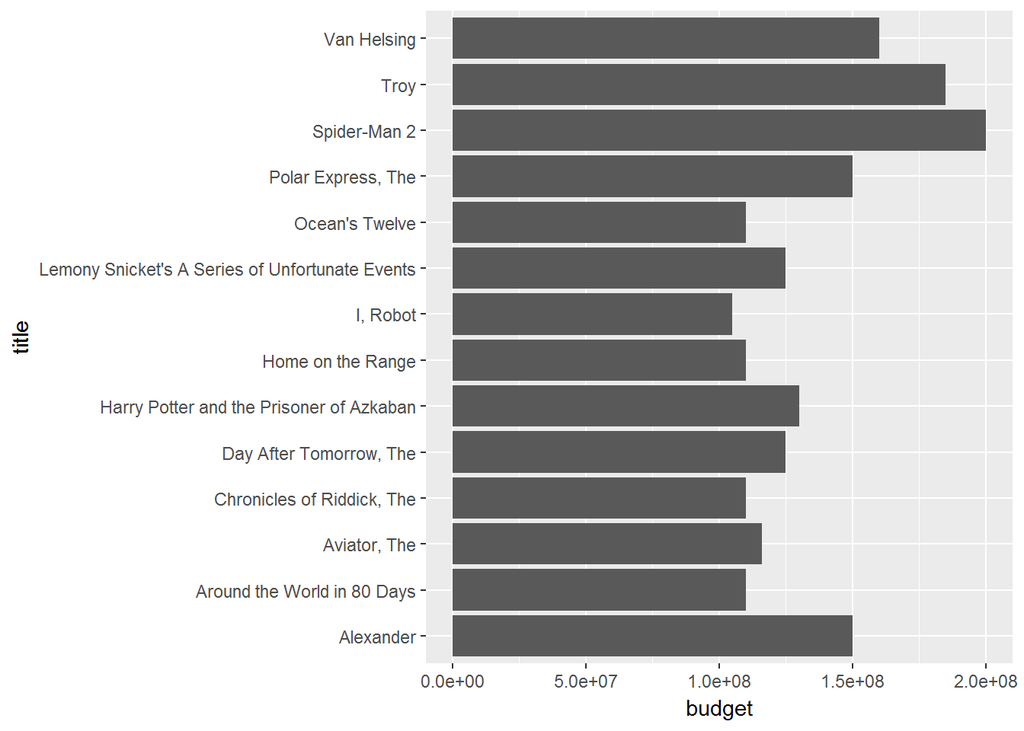

```r
filter(movies, year == 2004, budget > 100000000) %>%
    ggplot() +
    geom_col(aes(title, budget)) +
    coord_flip()
```

To do this, we can use the `reorder` function. The reorder function has two arguments: the variable to reorder, in this case the movie titles, and the variable to use for reordering, in this case the budget.

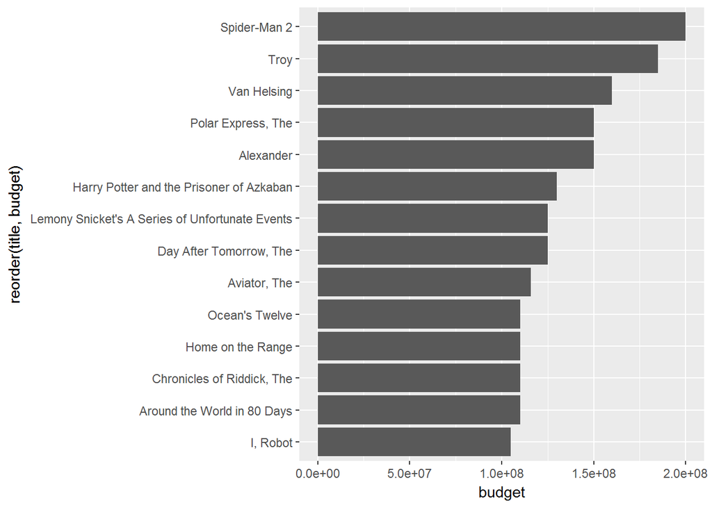

```r
filter(movies, year == 2004, budget > 100000000) %>%
    ggplot() +
    geom_col(aes(reorder(title, budget), budget)) +
    coord_flip()
```

Can you find how to reorder the movies in the reverse direction?

## Combining multiple geometric layers

So far, we only used one geometric layer at a time. However, it is perfectly possible to combine different layers. For instance, we can use the `geom_text` label to add data labels to a bar plot. Geom_text is a geometric layer which we can use, indeed, to put text in a graph. We didn’t see geom_text before, however, its working will be straigtforward, based on all the things we already know. We build further upon the last graph, which we have given a slightly nicer appearance

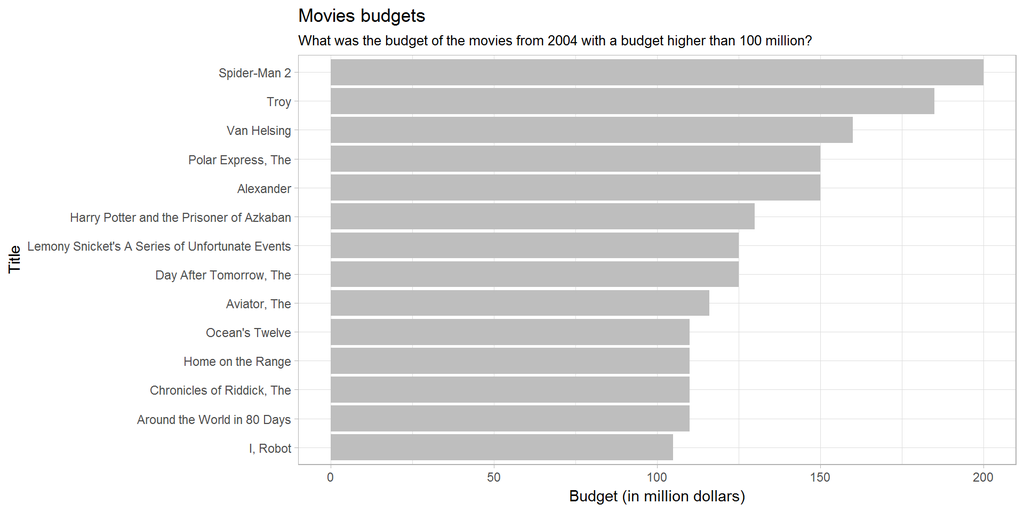

```r
filter(movies, year == 2004, budget > 100000000) %>%
    ggplot() +
    geom_col(aes(reorder(title, budget), budget/1000000), fill = "grey") +
    coord_flip() +
    labs(title = "Movies budgets",
         subtitle = "What was the budget of the movies from 2004 with a budget higher than 100 million?",
         x = "Title",
         y = "Budget (in million dollars)") +
    theme_light()
```

Note that we changed the y-aesthetic to budget/1000000, such that the values are in millions. Furthermore, it is important to remark that, since we used coord_flip, our labels set in labs also switched. Thus the x-label appears on the y-axis and the y-label on the x-axis. This is exactly what we would prefer, as removing coord_flip in the future won’t mess up the labels.

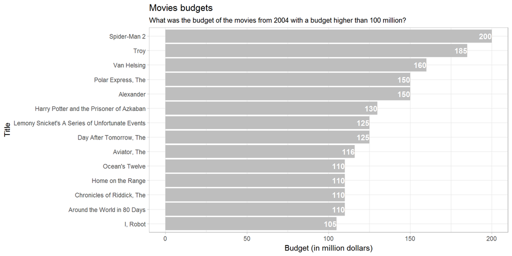

```r
filter(movies, year == 2004, budget > 100000000) %>%
    ggplot() +
    geom_col(aes(reorder(title, budget), budget/1000000), fill = "grey") +
    geom_text(aes(reorder(title, budget), budget/1000000,
                  label = budget/1000000), color = "white", fontface = "bold", hjust = 1) +
    coord_flip() +
    labs(title = "Movies budgets",
         subtitle = "What was the budget of the movies from 2004 with a budget higher than 100 million?",
         x = "Title",
         y = "Budget (in million dollars)") +
    theme_light()
```

The addition of the second geom layer seemed a little bit cumbersome, as we needed to repeat the mapping for x and y, which was made even worse because it involved the reorder function and the division by a million. Surely, there is a better way to do this? We call it aes-inheritance.

## Aes-inheritance

Aes-inheritance, or inheritance of the aes-mapping, means that each of the geom layers which is added to a `ggplot` call *inherits* the mapping which is specified in that ggplot function call. As you may remember from the very beginning, an aes-mapping can be placed in both geom layers as in ggplot. In the end, we learn there is a little but importance difference.

When different layers have (part of) a mapping in common, it is best practice to move this part to the `ggplot` call. As such, you don’t have to repeat this in any of the layers which use it. And, if any of the layers doesn’t use this mapping, you can easily overwrite it by specifying a new mapping whithin that layer. Let’s look at an example.

The previous plot we made can more easily be made as follows:

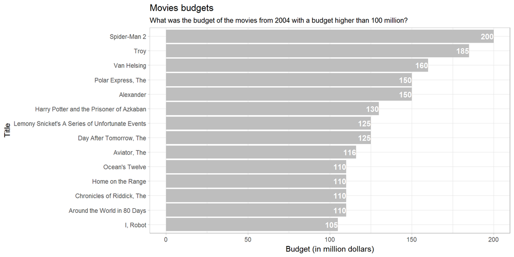

```r
filter(movies, year == 2004, budget > 100000000) %>%
    ggplot(aes(reorder(title, budget), budget/1000000)) +
    geom_col(fill = "grey") +
    geom_text(aes(label = budget/1000000), color = "white", fontface = "bold", hjust = 1) +
    coord_flip() +
    labs(title = "Movies budgets",
         subtitle = "What was the budget of the movies from 2004 with a budget higher than 100 million?",
         x = "Title",
         y = "Budget (in million dollars)") +
    theme_light()
```

By moving the mapping for x and y to ggplot, there is no mapping needed in geom_col, and only a mapping for label in geom_text. Both geom layers inherit the other part of the mapping for the ggplot function call. Truly, this seems far more efficient!

# Background material

By now you already master a great deal of plotting with ggplot2. You have both learned how to use different geometric layers to represent data, how to combine them, how to use facets, how to make your code more efficient using aes-inheritance, and last but not least, how to give your plot a nice appearance. Congratulations!

If you are eager to learn even more, you might have a look at the following background materials:

- [The ggplot Cheat Sheet](https://www.rstudio.com/wp-content/uploads/2015/03/ggplot2-cheatsheet.pdf), which provides an overview of all basic functionality in the ggplot2 package.
- [The ggplot documentation](http://docs.ggplot2.org/current/)
- [An even more comprehensive ggplot2 tutorial](http://tutorials.iq.harvard.edu/R/Rgraphics/Rgraphics.html)